# Ford Gobike trip data

## by Mohamed Abdeen

## Preliminary Wrangling

> This dataset explores a Ford Gobike trip data containing more than 180k entries with 16 features (duration_sec, start_time, end_time, start_station_id, start_station_name, start_station_latitude, start_station_longitude, end_station_id, end_station_name, end_station_latitude ,end_station_longitude, bike_id, user_type, member_birth_year, member_gender, bike_share_for_all_trip).

# Number of trips to Trip Duration

> This graph shows that the number of trips is mostly centered around 500 seconds. Number of Trips values increase reaching as high as 25000 trips and then dipping back down as trip duration increases.

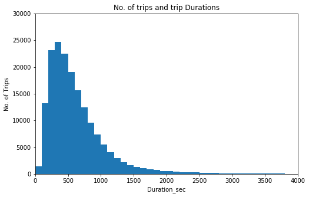

```python
#Let's check duration_sec
binsize = 100
bins = np.arange(0, df['duration_sec'].max()+binsize, binsize)

plt.figure(figsize=[8, 5])
plt.hist(data = df, x = 'duration_sec', bins = bins)
plt.title('No. of trips and trip Durations')
plt.xlabel('Duration_sec')
plt.ylabel('No. of Trips')
plt.axis([0,4000, 0, 30000])
plt.show()
```

# Number of users to Age

> As you can see below, Most of the customers are ditributed between 20 to 40 years old.

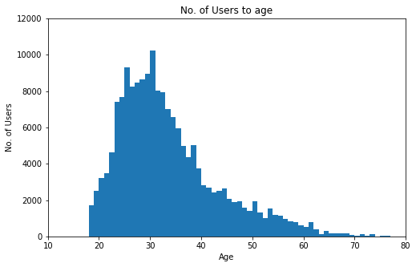

```python
# Age
binsize = 1
bins = np.arange(0, df['member_birth_year'].max()+binsize, binsize)

plt.figure(figsize=[8, 5])
plt.hist(data = df, x = 'member_birth_year', bins = bins)
plt.axis([1939, 2009, 0, 12000])
plt.xticks([1939, 1949, 1959, 1969, 1979, 1989, 1999, 2009], [(2019-1939), (2019-1949), (2019-1959), (2019-1969), (2019-1979), (2019-1989), (2019-1999), (2019-2009)])
plt.gca().invert_xaxis()
plt.title('No. of Users to age')
plt.xlabel('Age')
plt.ylabel('No. of Users')
plt.show()
```

# Percentage of Trips per User Type

> As You can see, this graph suggests that most users prefer to be subscribers rather than customers. Probably due to subscriber packages that offer lower price. This is just a guess as marketing data are not provided.

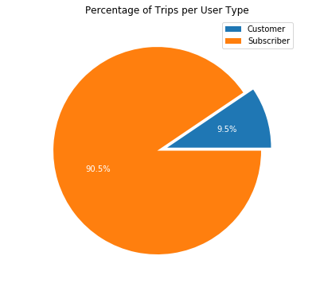

```python
# User type
total_trips = df['duration_sec'].count()
c_trips = df[df['user_type']=='Customer']['duration_sec'].count() / total_trips
s_trips = df[df['user_type']=='Subscriber']['duration_sec'].count() / total_trips

plt.figure(figsize=(6,6))
plt.pie([c_trips,s_trips], explode=(0, 0.1), labels=['Customer', 'Subscriber'],
        autopct='%1.1f%%', startangle=0, textprops={'color':'white'})
plt.title("Percentage of Trips per User Type")
plt.legend()
plt.show()
```

# Gender

> This suggests that most of the users are male at 74.6%, followed by females at 23% and then Other who only make up a little above 2%.

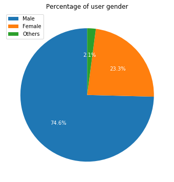

```python
# Gender
male = (df['member_gender'] == 'Male').sum()
female = (df['member_gender'] == 'Female').sum()
other = (df['member_gender'] == 'Other').sum()
total = df['member_gender'].count()
plt.figure(figsize=(6,6))
plt.pie([male,female,other], labels=['Male', 'Female', 'Others'],
        autopct='%1.1f%%', startangle=90, textprops={'color':'white'})
plt.title("Percentage of user gender")
plt.legend()
plt.show()
```

# Number of Trips per day

> The graph below shows that there are a lot more trips during weekdays than weekends

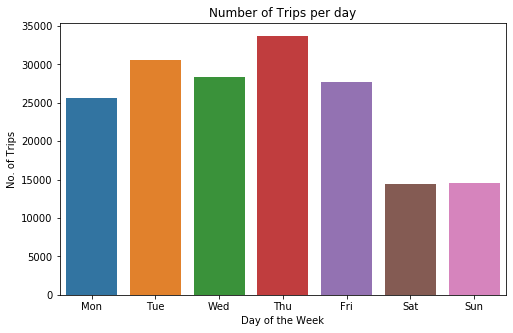

```python
day_order = ['Mon', 'Tue', 'Wed', 'Thu', 'Fri', 'Sat', 'Sun']

plt.figure(figsize=(8,5))
sb.countplot(x = df['start_time'].dt.strftime('%a'),data=df, order = day_order)
plt.title("Number of Trips per day")
plt.xlabel('Day of the Week')
plt.ylabel('No. of Trips');
plt.show()
```

# Number of trips by hour of day

> This graph along with the one before suggest that most of the trips are done during rush hour, ie., to & from work. which is further proven when number of trips fall on weekends.

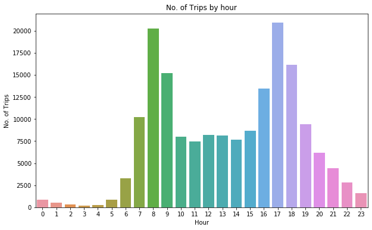

```python
plt.figure(figsize=(10,6))
sb.countplot(x = df['start_time'].dt.hour.astype(int),data=df)
plt.title("No. of Trips by hour")
plt.xlabel('Hour')
plt.ylabel('No. of Trips');
plt.show()
```

# Trip Duration per Weekday

> This graph suggests that during weekdays the trips are mostly less than 10 minutes with longer durations on weekends.

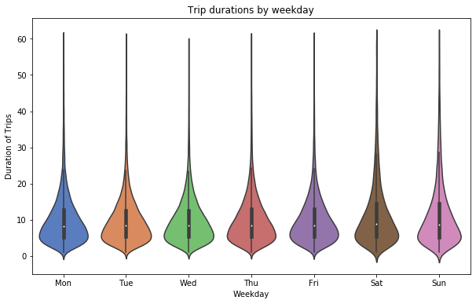

```python
day_order = ['Mon', 'Tue', 'Wed', 'Thu', 'Fri', 'Sat', 'Sun']

plt.figure(figsize=(10,6))
sb.violinplot(x='start_time_day', y='duration_min', data=df[df['duration_min']<60], palette='muted', order = day_order)
plt.title("Trip durations by weekday")
plt.xlabel('Weekday')
plt.ylabel('Duration of Trips');
plt.show()
```

# Comparison between No. of trips on work days & Weekends

> The plot below suggests what we have already figured out; There are larger amount of trips during weekdays rather than weekends.

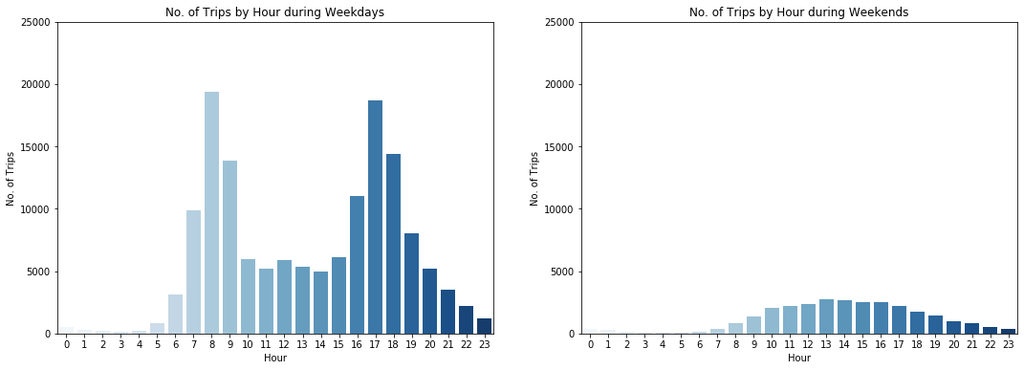

```python
plt.figure(figsize=(18,6))

plt.subplot(1, 2, 1) # 1 row, 2 cols, subplot 1
fig1 = sb.countplot(x='start_time_hr', data=df[df['wkday_wkend']=='Weekday'], palette='Blues')
plt.title("No. of Trips by Hour during Weekdays")
plt.xlabel('Hour')
plt.ylabel('No. of Trips')
plt.ylim([0,25000])


plt.subplot(1, 2, 2) # 1 row, 2 cols, subplot 1
fig1 = sb.countplot(x='start_time_hr', data=df[df['wkday_wkend']=='Weekend'], palette='Blues')
plt.title("No. of Trips by Hour during Weekends")
plt.xlabel('Hour')
plt.ylabel('No. of Trips')
plt.ylim([0,25000])
plt.show()
```

# Gender and trip duration

> This graph suggests puts into perspective that 'Other' are has lower density to either male or female category especially above age 60.

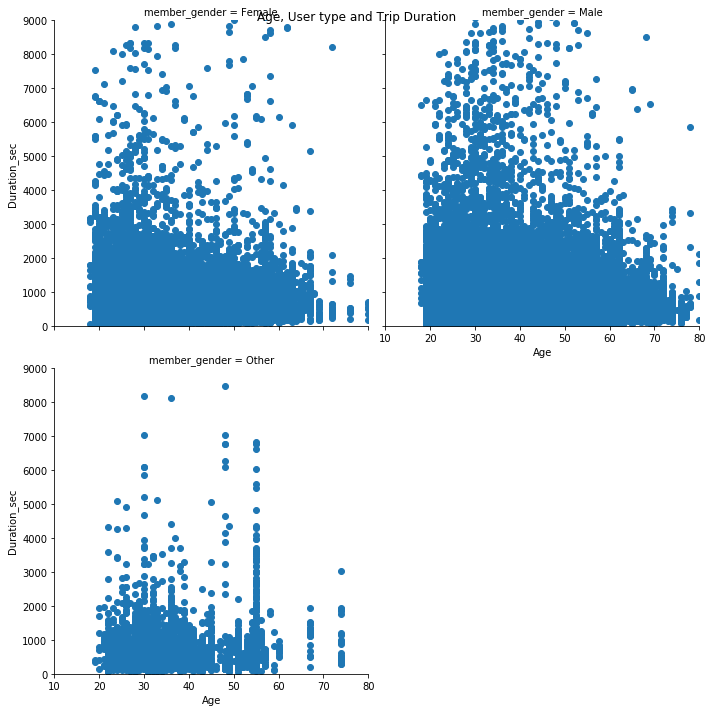

```python
df['age'] = (2019 - df['member_birth_year'])
gender = sb.FacetGrid(data = df, col = 'member_gender', col_wrap = 2, size = 5,
                 xlim = [10, 80], ylim = [0, 9000])
gender.map(plt.scatter, 'age', 'duration_sec', alpha= 1)

gender.set_xlabels('Age')
gender.set_ylabels('Duration_sec')
gender.fig.suptitle('Age, User type and Trip Duration');
plt.show()
```

# User type and Trip duration

> This graph implies that subscribers have higher density especially among users older than 60.

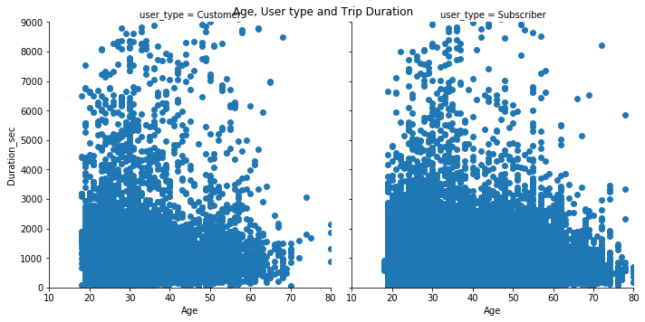

```python
user_type = sb.FacetGrid(data = df, col = 'user_type', col_wrap = 2, size = 5,
                 xlim = [10, 80], ylim = [0, 9000])
user_type.map(plt.scatter, 'age', 'duration_sec', alpha= 1)

user_type.set_xlabels('Age')
user_type.set_ylabels('Duration_sec')
user_type.fig.suptitle('Age, User type and Trip Duration')
plt.show()
```